# Lakers

Data from: http://www.basketballgeek.com/data/

## 1.데이터 확인

```python
#한글 폰트 설정하기
!sudo apt-get install -y fonts-nanum
!sudo fc-cache -fv
!rm ~/.cache/matplotlib -rf
#런타임 다시 시작
```

[output not shown]

```python
#기본 패키지
import math
import numpy as np
import pandas as pd
import seaborn as sns
import matplotlib.pyplot as plt

plt.style.use('seaborn')
sns.set(font_scale=1)
plt.rc('font', family='NanumBarunGothic')
plt.rcParams['font.family'] = 'NanumGothic'

import warnings
warnings.simplefilter(action='ignore', category=FutureWarning)
```

```python
#구글 드라이브 마운트
from google.colab import drive
drive.mount('/content/drive')
```

```python
#데이터 불러오기 csv 데이터 파일
lakers = pd.read_csv('/content/drive/MyDrive/Colab Notebooks/데이터 분석 실습/LAkers/Lakers.csv')
```

<컬럼 설명>

- Date: 경기 일자
- Opponent: 대전 팀
- Game type: 홈경기 vs. 원정경기
- Time: 분 : 초
- Period: 쿼터(한 쿼터당 12분 씩, 동점일 경우 5 쿼터 진행)
- Etype: 유형(ejection / foul / free throw / jump ball / rebound / shot / sub / timeout / turnover / violation 퇴장 / 파울 / 자유투/ 점프볼/ 리바운드/ 슛/ 패스 / 타임아웃/ 턴오버/ 반칙)
- Team: 팀 구분(LAL: LA Lakers, 상대팀)
- Player: 선수명
- Result: 결과
- Points: 점수
- Type: 세부행동
- X, Y: 상대편 팀 골대 뒤에서 바라본 X, Y 좌표. 골대의 위치는 (25, 5.25)이다.
- 범주형 변수: *빈도frequency 계산 가능*

  ```
           opponent, game_type, period, etype, team, player, resuts, type
  ```

- 연속형 변수: *평균, 표준편차, min/max 등 수치 계산 가능*

  ```
           시간 변수(date, time), result, x, y
  ```

```python
#범주형 데이터의 통계치 확인
lakers.describe(include=np.object)
```

|  | opponent | game_type | time | etype | team | player | result | type |
| --- | --- | --- | --- | --- | --- | --- | --- | --- |
| count | 34624 | 34624 | 34624 | 34624 | 34624 | 29231 | 16888 | 24242 |
| unique | 29 | 2 | 717 | 10 | 31 | 370 | 2 | 73 |
| top | DEN | home | 0:00 | shot | LAL | Kobe Bryant | made | def |
| freq | 1855 | 17471 | 357 | 13108 | 17235 | 2945 | 8916 | 4768 |

```python
print('Oppenent: ', lakers['opponent'].unique())
print('Game type: ', lakers['game_type'].unique())
print('Period: ', lakers['period'].unique())
print('Etype: ', lakers['etype'].unique())
print('Team: ', lakers['team'].unique())
print('Result: ', lakers['result'].unique())
print('Points: ', lakers['points'].unique())
print('Type: ', lakers['type'].unique())
```

```
Oppenent:  ['POR' 'LAC' 'DEN' 'HOU' 'DAL' 'DET' 'CHI' 'PHX' 'SAC' 'NJN' 'TOR' 'IND'
 'PHI' 'WAS' 'MIL' 'MIN' 'NYK' 'MIA' 'ORL' 'MEM' 'NOH' 'BOS' 'UTA' 'GSW'
 'SAS' 'CLE' 'OKC' 'ATL' 'CHA']
Game type:  ['home' 'away']
Period:  [1 2 3 4 5]
Etype:  ['jump ball' 'shot' 'rebound' 'foul' 'free throw' 'turnover' 'timeout'
 'sub' 'violation' 'ejection']
Team:  ['OFF' 'LAL' 'POR' 'LAC' 'DEN' 'HOU' 'DAL' 'DET' 'CHI' 'PHX' 'SAC' 'NJN'
 'TOR' 'IND' 'PHI' 'WAS' 'MIL' 'MIN' 'NYK' 'MIA' 'ORL' 'MEM' 'NOH' 'BOS'
 'UTA' 'GSW' 'SAS' 'CLE' 'OKC' 'ATL' 'CHA']
Result:  [nan 'missed' 'made']
Points:  [0 2 1 3]
Type:  [nan 'hook' 'off' 'layup' 'shooting' 'personal' 'jump' 'pullup jump' 'def'
 'driving layup' 'driving finger roll layup' 'regular' 'offensive' '3pt'
 'turnaround jump' 'putback layup' 'slam dunk' 'tip' 'dunk'
 'defensive goaltending' 'hook bank' 'running layup' 'official'
 'driving slam dunk' 'short' 'driving reverse layup' 'kicked ball'
 'putback dunk' 'technical' 'alley oop dunk' 'turnaround fade away'
 'running jump' 'delay of game' 'defense 3 second' 'fade away bank'
 'floating jump' 'driving dunk' 'loose ball' 'running bank' 'running dunk'
 'fade away jumper' 'finger roll layup' 'turnaround hook' 'reverse layup'
 'reverse dunk' 'jump hook' 'jump bank' 'double technical' 'running hook'
 'driving jump' 'turnaround bank' 'step back jump' 'turnaround bank hook'
 'pullup bank' 'alley oop layup' 'putback slam dunk' 'flagrant type 1'
 'running reverse layup' 'running finger roll layup' 'reverse slam dunk'
 'hanging technical' 'running slam dunk' 'driving bank hook' 'jump ball'
 'away from play' 'double personal' 'driving bank' 'running bank hook'
 'driving hook' 'lane' 'clear path' 'jump bank hook' 'flagrant type 2'
 'inbound']
```

```python
#데이터 내용 요약
print("총 데이터 개수: ", lakers.shape[0]*lakers.shape[1])
print("총 결측치 수: {} = 전체 데이터의 {:.2f}% ".format(lakers.isnull().sum().sum(), (lakers.isnull().sum().sum()*100)/(lakers.shape[0]*lakers.shape[1])))
print("LA 레이커스와 경기한 팀 수: ", lakers['opponent'].nunique()-1)
print("경기에 등장하는 행동 수: ", lakers['etype'].nunique())
print("경기에 등장하는 세부행동 수: ", lakers['type'].nunique())
```

[output not shown]

## 2.분석 내용

- LA레이커스의 홈 경기 vs. 원정경기 비율
- 경기에서 선수들이 가장 많이 하는 행동유형(etype)?
- 2008-2009 시즌에서 LA레이커스의 경기 결과
- LA레이커스 선수들의 코트 위치별 동작 유형

## 3.데이터 전처리

### 3-1. 시간 타입의 컬럼 정비

```python
#column 병합 date - datetime
lakers['date'] = lakers['date'].apply(str)
lakers['datetime'] = lakers['date'] + ' ' + lakers['time']
lakers.head()
```

|  | date | opponent | game_type | time | period | etype | team | player | result | points | type | x | y | datetime |
| --- | --- | --- | --- | --- | --- | --- | --- | --- | --- | --- | --- | --- | --- | --- |
| 0 | 20081028 | POR | home | 12:00 | 1 | jump ball | OFF | NaN | NaN | 0 | NaN | NaN | NaN | 20081028 12:00 |
| 1 | 20081028 | POR | home | 11:39 | 1 | shot | LAL | Pau Gasol | missed | 0 | hook | 23.0 | 13.0 | 20081028 11:39 |
| 2 | 20081028 | POR | home | 11:37 | 1 | rebound | LAL | Vladimir Radmanovic | NaN | 0 | off | NaN | NaN | 20081028 11:37 |
| 3 | 20081028 | POR | home | 11:25 | 1 | shot | LAL | Derek Fisher | missed | 0 | layup | 25.0 | 6.0 | 20081028 11:25 |
| 4 | 20081028 | POR | home | 11:23 | 1 | rebound | LAL | Pau Gasol | NaN | 0 | off | NaN | NaN | 20081028 11:23 |

```python
#date 컬럼 & datetime 컬럼 -> 날짜 타입
lakers['datetime'] = pd.to_datetime(lakers['datetime'],format='%Y%m%d %H:%M:%S')
lakers['date'] = pd.to_datetime(lakers['date'],format='%Y%m%d')
lakers.head()
```

|  | date | opponent | game_type | time | period | etype | team | player | result | points | type | x | y | datetime |
| --- | --- | --- | --- | --- | --- | --- | --- | --- | --- | --- | --- | --- | --- | --- |
| 0 | 2008-10-28 | POR | home | 12:00 | 1 | jump ball | OFF | NaN | NaN | 0 | NaN | NaN | NaN | 2008-10-28 12:00:00 |
| 1 | 2008-10-28 | POR | home | 11:39 | 1 | shot | LAL | Pau Gasol | missed | 0 | hook | 23.0 | 13.0 | 2008-10-28 11:39:00 |
| 2 | 2008-10-28 | POR | home | 11:37 | 1 | rebound | LAL | Vladimir Radmanovic | NaN | 0 | off | NaN | NaN | 2008-10-28 11:37:00 |
| 3 | 2008-10-28 | POR | home | 11:25 | 1 | shot | LAL | Derek Fisher | missed | 0 | layup | 25.0 | 6.0 | 2008-10-28 11:25:00 |
| 4 | 2008-10-28 | POR | home | 11:23 | 1 | rebound | LAL | Pau Gasol | NaN | 0 | off | NaN | NaN | 2008-10-28 11:23:00 |

### 3-2. 결측치 처리하기

```python
#NULL
lakers.isnull().any(axis=0)
#player, result, type, x, y 컬럼
```

```
date         False
opponent     False
game_type    False
time         False
period       False
etype        False
team         False
player        True
result        True
points       False
type          True
x             True
y             True
datetime     False
dtype: bool
```

```python
print(lakers.index[lakers['x'] == '0'].tolist())
print(lakers.index[lakers['y'] == '0'].tolist())
#nothing
```

```
[]
[]
```

```python
#x, y position - NaN -> 0
lakers['x'].fillna(0, inplace=True)
lakers['y'].fillna(0, inplace=True)
lakers.head()
```

|  | date | opponent | game_type | time | period | etype | team | player | result | points | type | x | y | datetime |
| --- | --- | --- | --- | --- | --- | --- | --- | --- | --- | --- | --- | --- | --- | --- |
| 0 | 2008-10-28 | POR | home | 12:00 | 1 | jump ball | OFF | NaN | NaN | 0 | NaN | 0.0 | 0.0 | 2008-10-28 12:00:00 |
| 1 | 2008-10-28 | POR | home | 11:39 | 1 | shot | LAL | Pau Gasol | missed | 0 | hook | 23.0 | 13.0 | 2008-10-28 11:39:00 |
| 2 | 2008-10-28 | POR | home | 11:37 | 1 | rebound | LAL | Vladimir Radmanovic | NaN | 0 | off | 0.0 | 0.0 | 2008-10-28 11:37:00 |
| 3 | 2008-10-28 | POR | home | 11:25 | 1 | shot | LAL | Derek Fisher | missed | 0 | layup | 25.0 | 6.0 | 2008-10-28 11:25:00 |
| 4 | 2008-10-28 | POR | home | 11:23 | 1 | rebound | LAL | Pau Gasol | NaN | 0 | off | 0.0 | 0.0 | 2008-10-28 11:23:00 |

## 4.EDA & Visualizaion

### 4-1. 홈 경기 대 원정 경기의 비율

```python
#Home or Away
lakers[['date','game_type']].groupby(['date','game_type']).sum()
```

| date | game_type |
| --- | --- |
| 2008-10-28 | home |
| 2008-10-29 | away |
| 2008-11-01 | away |
| 2008-11-05 | home |
| 2008-11-09 | home |
| ... | ... |
| 2009-04-07 | away |
| 2009-04-09 | home |
| 2009-04-10 | away |
| 2009-04-12 | home |
| 2009-04-14 | home |

78 rows × 0 columns

```python
lakers[['date','game_type']].groupby(['date','game_type']).sum().reset_index()
```

|  | date | game_type |
| --- | --- | --- |
| 0 | 2008-10-28 | home |
| 1 | 2008-10-29 | away |
| 2 | 2008-11-01 | away |
| 3 | 2008-11-05 | home |
| 4 | 2008-11-09 | home |
| ... | ... | ... |
| 73 | 2009-04-07 | away |
| 74 | 2009-04-09 | home |
| 75 | 2009-04-10 | away |
| 76 | 2009-04-12 | home |
| 77 | 2009-04-14 | home |

78 rows × 2 columns

```python
#홈 경기 대 원정 경기의 비율:
df1 = lakers.drop_duplicates(['date'], keep='first')
df1
```

|  | date | opponent | game_type | time | period | etype | team | player | result | points | type | x | y | datetime |
| --- | --- | --- | --- | --- | --- | --- | --- | --- | --- | --- | --- | --- | --- | --- |
| 0 | 2008-10-28 | POR | home | 12:00 | 1 | jump ball | OFF | NaN | NaN | 0 | NaN | 0.0 | 0.0 | 2008-10-28 12:00:00 |
| 416 | 2008-10-29 | LAC | away | 12:00 | 1 | jump ball | OFF | NaN | NaN | 0 | NaN | 0.0 | 0.0 | 2008-10-29 12:00:00 |
| 871 | 2008-11-01 | DEN | away | 12:00 | 1 | jump ball | OFF | NaN | NaN | 0 | NaN | 0.0 | 0.0 | 2008-11-01 12:00:00 |
| 1364 | 2008-11-05 | LAC | home | 12:00 | 1 | jump ball | OFF | NaN | NaN | 0 | NaN | 0.0 | 0.0 | 2008-11-05 12:00:00 |
| 1867 | 2008-11-09 | HOU | home | 12:00 | 1 | jump ball | OFF | NaN | NaN | 0 | NaN | 0.0 | 0.0 | 2008-11-09 12:00:00 |
| ... | ... | ... | ... | ... | ... | ... | ... | ... | ... | ... | ... | ... | ... | ... |
| 32345 | 2009-04-07 | SAC | away | 12:00 | 1 | jump ball | OFF | NaN | NaN | 0 | NaN | 0.0 | 0.0 | 2009-04-07 12:00:00 |
| 32782 | 2009-04-09 | DEN | home | 12:00 | 1 | jump ball | OFF | NaN | NaN | 0 | NaN | 0.0 | 0.0 | 2009-04-09 12:00:00 |
| 33280 | 2009-04-10 | POR | away | 12:00 | 1 | jump ball | OFF | NaN | NaN | 0 | NaN | 0.0 | 0.0 | 2009-04-10 12:00:00 |
| 33746 | 2009-04-12 | MEM | home | 12:00 | 1 | jump ball | OFF | NaN | NaN | 0 | NaN | 0.0 | 0.0 | 2009-04-12 12:00:00 |
| 34153 | 2009-04-14 | UTA | home | 12:00 | 1 | jump ball | OFF | NaN | NaN | 0 | NaN | 0.0 | 0.0 | 2009-04-14 12:00:00 |

78 rows × 14 columns

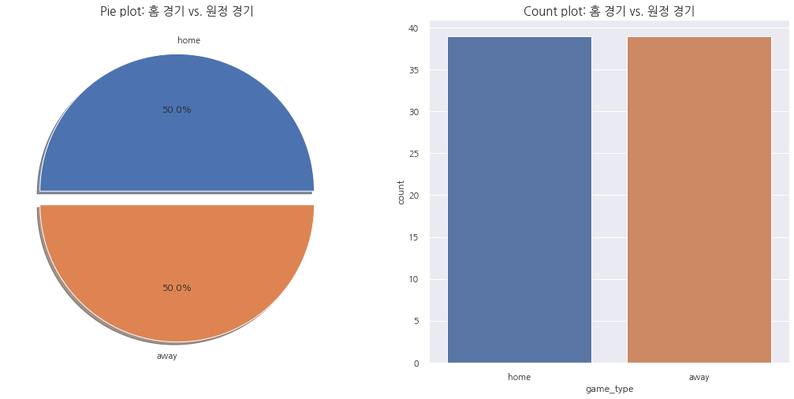

```python
#홈 경기 대 원정 경기의 비율: 그래프
f, ax = plt.subplots(1, 2, figsize=(18, 8))

#pie plot
df1['game_type'].value_counts().plot.pie(explode=[0, 0.1], autopct='%1.1f%%', ax=ax[0], shadow=True)
ax[0].set_title('Pie plot: 홈 경기 vs. 원정 경기', size = 15)
ax[0].set_ylabel('') #y 라벨 없애기

#count plot
sns.countplot('game_type', data=df1, ax=ax[1])
ax[1].set_title('Count plot: 홈 경기 vs. 원정 경기', size = 15)

plt.show()
```

### 4-2.경기에서 발생한 행동 유형 확인

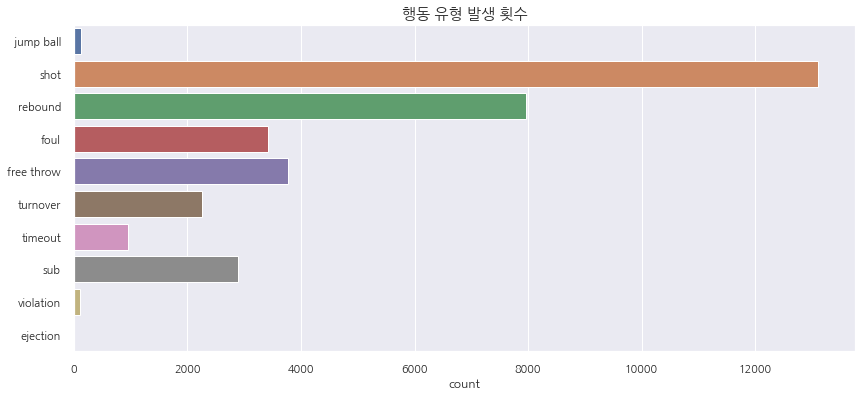

```python
#행동유형 발생 횟수
f, ax = plt.subplots(1, 1, figsize=(14, 6))

sns.countplot(y=lakers['etype'], ax=ax)
ax.set_title('행동 유형 발생 횟수', size=15)
ax.set_ylabel('')

plt.show()
```

```python
#특정 쿼터별 행동
df2 = lakers.groupby(['etype','period']).size()
df2
```

```
etype       period
ejection    3            1
foul        1          665
            2          887
            3          848
            4         1002
            5           15
free throw  1          666
            2          944
            3          949
            4         1205
            5           16
jump ball   1           85
            2           16
            3            7
```

[output cut: 32 more lines]

```python
df2 = lakers.groupby(['etype','period']).size().reset_index()
df2
```

|  | etype | period | 0 |
| --- | --- | --- | --- |
| 0 | ejection | 3 | 1 |
| 1 | foul | 1 | 665 |
| 2 | foul | 2 | 887 |
| 3 | foul | 3 | 848 |
| 4 | foul | 4 | 1002 |
| 5 | foul | 5 | 15 |
| 6 | free throw | 1 | 666 |
| 7 | free throw | 2 | 944 |
| 8 | free throw | 3 | 949 |
| 9 | free throw | 4 | 1205 |
| 10 | free throw | 5 | 16 |
| 11 | jump ball | 1 | 85 |
| 12 | jump ball | 2 | 16 |
| 13 | jump ball | 3 | 7 |
| 14 | jump ball | 4 | 21 |
| 15 | jump ball | 5 | 2 |
| 16 | rebound | 1 | 2023 |
| 17 | rebound | 2 | 1966 |
| 18 | rebound | 3 | 1986 |
| 19 | rebound | 4 | 1976 |
| 20 | rebound | 5 | 20 |
| 21 | shot | 1 | 3500 |
| 22 | shot | 2 | 3279 |
| 23 | shot | 3 | 3232 |
| 24 | shot | 4 | 3063 |
| 25 | shot | 5 | 34 |
| 26 | sub | 1 | 555 |
| 27 | sub | 2 | 915 |
| 28 | sub | 3 | 584 |
| 29 | sub | 4 | 832 |
| 30 | sub | 5 | 5 |
| 31 | timeout | 1 | 166 |
| 32 | timeout | 2 | 266 |
| 33 | timeout | 3 | 185 |
| 34 | timeout | 4 | 327 |
| 35 | timeout | 5 | 6 |
| 36 | turnover | 1 | 547 |
| 37 | turnover | 2 | 571 |
| 38 | turnover | 3 | 533 |
| 39 | turnover | 4 | 608 |
| 40 | turnover | 5 | 2 |
| 41 | violation | 1 | 25 |
| 42 | violation | 2 | 35 |
| 43 | violation | 3 | 27 |
| 44 | violation | 4 | 27 |

```python
df2 = lakers.groupby(['etype','period']).size().reset_index().pivot(columns='period',index='etype', values=0)
df2
```

| period etype | 1 | 2 | 3 | 4 | 5 |
| --- | --- | --- | --- | --- | --- |
| ejection | NaN | NaN | 1.0 | NaN | NaN |
| foul | 665.0 | 887.0 | 848.0 | 1002.0 | 15.0 |
| free throw | 666.0 | 944.0 | 949.0 | 1205.0 | 16.0 |
| jump ball | 85.0 | 16.0 | 7.0 | 21.0 | 2.0 |
| rebound | 2023.0 | 1966.0 | 1986.0 | 1976.0 | 20.0 |
| shot | 3500.0 | 3279.0 | 3232.0 | 3063.0 | 34.0 |
| sub | 555.0 | 915.0 | 584.0 | 832.0 | 5.0 |
| timeout | 166.0 | 266.0 | 185.0 | 327.0 | 6.0 |
| turnover | 547.0 | 571.0 | 533.0 | 608.0 | 2.0 |
| violation | 25.0 | 35.0 | 27.0 | 27.0 | NaN |

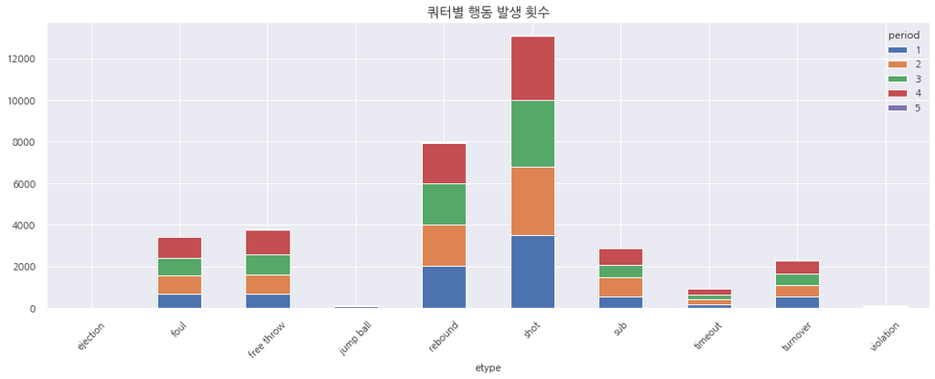

```python
#stack plot
df2.plot(kind='bar', stacked=True, figsize=(18, 6))
plt.title('쿼터별 행동 발생 횟수', size=15)
plt.xticks(rotation=45)

plt.show()
```

### 4-3. 경기 결과 집계하고 시계열 그래프로 그리기

```python
#날짜별 경기 결과
made = lakers['result'].isin(['made'])
lakers[made].head()
```

|  | date | opponent | game_type | time | period | etype | team | player | result | points | type | x | y | datetime |
| --- | --- | --- | --- | --- | --- | --- | --- | --- | --- | --- | --- | --- | --- | --- |
| 5 | 2008-10-28 | POR | home | 11:22 | 1 | shot | LAL | Pau Gasol | made | 2 | hook | 25.0 | 10.0 | 2008-10-28 11:22:00 |
| 7 | 2008-10-28 | POR | home | 11:22 | 1 | free throw | LAL | Pau Gasol | made | 1 | NaN | 0.0 | 0.0 | 2008-10-28 11:22:00 |
| 9 | 2008-10-28 | POR | home | 10:53 | 1 | shot | POR | LaMarcus Aldridge | made | 2 | jump | 36.0 | 21.0 | 2008-10-28 10:53:00 |
| 10 | 2008-10-28 | POR | home | 10:45 | 1 | shot | LAL | Derek Fisher | made | 2 | pullup jump | 30.0 | 21.0 | 2008-10-28 10:45:00 |
| 13 | 2008-10-28 | POR | home | 10:21 | 1 | shot | LAL | Pau Gasol | made | 2 | jump | 15.0 | 17.0 | 2008-10-28 10:21:00 |

```python
#날짜별 팀별 슛 성공 건수를 집계
df3 = lakers[made][['date', 'team', 'points']].groupby(['date', 'team'], as_index=True).sum()
df3
```

| date | team | points |
| --- | --- | --- |
| 2008-10-28 | LAL | 96 |
|  | POR | 76 |
| 2008-10-29 | LAC | 79 |
|  | LAL | 117 |
| 2008-11-01 | DEN | 97 |
| ... | ... | ... |
| 2009-04-10 | POR | 106 |
| 2009-04-12 | LAL | 92 |
|  | MEM | 75 |
| 2009-04-14 | LAL | 125 |
|  | UTA | 112 |

156 rows × 1 columns

```python
df3.reset_index(inplace=True)
df3
```

|  | date | team | points |
| --- | --- | --- | --- |
| 0 | 2008-10-28 | LAL | 96 |
| 1 | 2008-10-28 | POR | 76 |
| 2 | 2008-10-29 | LAC | 79 |
| 3 | 2008-10-29 | LAL | 117 |
| 4 | 2008-11-01 | DEN | 97 |
| ... | ... | ... | ... |
| 151 | 2009-04-10 | POR | 106 |
| 152 | 2009-04-12 | LAL | 92 |
| 153 | 2009-04-12 | MEM | 75 |
| 154 | 2009-04-14 | LAL | 125 |
| 155 | 2009-04-14 | UTA | 112 |

156 rows × 3 columns

```python
lal = df3[df3['team'] == 'LAL']
opp = df3[df3['team'] != 'LAL']
```

```python
lal
```

|  | date | team | points |
| --- | --- | --- | --- |
| 0 | 2008-10-28 | LAL | 96 |
| 3 | 2008-10-29 | LAL | 117 |
| 5 | 2008-11-01 | LAL | 104 |
| 7 | 2008-11-05 | LAL | 106 |
| 9 | 2008-11-09 | LAL | 111 |
| ... | ... | ... | ... |
| 146 | 2009-04-07 | LAL | 122 |
| 149 | 2009-04-09 | LAL | 116 |
| 150 | 2009-04-10 | LAL | 98 |
| 152 | 2009-04-12 | LAL | 92 |
| 154 | 2009-04-14 | LAL | 125 |

78 rows × 3 columns

```python
df4 = pd.merge(lal, opp, on='date')
df4
```

|  | date | team_x | points_x | team_y | points_y |
| --- | --- | --- | --- | --- | --- |
| 0 | 2008-10-28 | LAL | 96 | POR | 76 |
| 1 | 2008-10-29 | LAL | 117 | LAC | 79 |
| 2 | 2008-11-01 | LAL | 104 | DEN | 97 |
| 3 | 2008-11-05 | LAL | 106 | LAC | 88 |
| 4 | 2008-11-09 | LAL | 111 | HOU | 82 |
| ... | ... | ... | ... | ... | ... |
| 73 | 2009-04-07 | LAL | 122 | SAC | 104 |
| 74 | 2009-04-09 | LAL | 116 | DEN | 102 |
| 75 | 2009-04-10 | LAL | 98 | POR | 106 |
| 76 | 2009-04-12 | LAL | 92 | MEM | 75 |
| 77 | 2009-04-14 | LAL | 125 | UTA | 112 |

78 rows × 5 columns

```python
#승패 나누기
win = df4[df4['points_x'] > df4['points_y']]
los = df4[df4['points_x'] < df4['points_y']]

print("08 - 09 시즌에 LA 레이커스는 총 {}회의 경기 중, {}번 우승했다".format(df4.shape[0], df4[df4['points_x'] > df4['points_y']].shape[0] ))
```

```
08 - 09 시즌에 LA 레이커스는 총 78회의 경기 중, 63번 우승했다
```

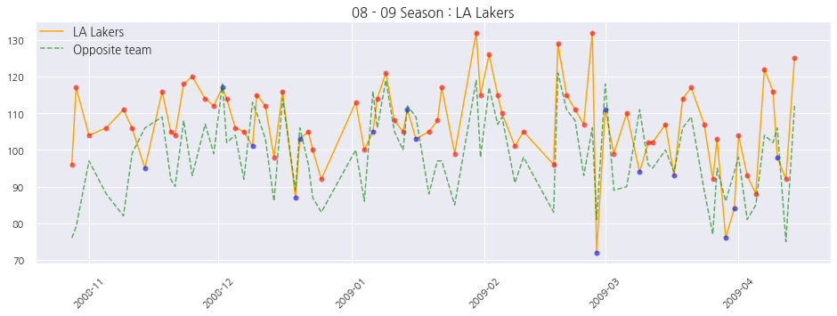

```python
#경기 결과를 시계열 그래프로 확인
plt.figure(figsize=(16,5))

plt.title("08 - 09 Season : LA Lakers", fontsize=15)

#LA 레이커스 점수 - Orange
plt.plot(lal['date'], lal['points'], "-", alpha= 1, color = 'orange', label='LA Lakers')

#LA 레이커스 승리 - red dot 패 - blue dot
plt.plot(win['date'], win["points_x"], 'o', alpha=.6, color = 'red')
plt.plot(los['date'], los["points_x"], 'o', alpha=.6, color = 'blue')

#상대팀 점수- Green
plt.plot(opp['date'], opp["points"], "--", alpha=.6, color = 'green', label='Opposite team')

plt.legend(loc='upper left', borderaxespad=0, fontsize=13)
plt.xticks(rotation=45)

plt.show()
```

### 4-4. LA레이커스 팀의 코트 위치별 행동

```python
#LA lakers 데이터
lal2 = lakers[lakers['team'] == 'LAL']
lal2
```

|  | date | opponent | game_type | time | period | etype | team | player | result | points | type | x | y | datetime |
| --- | --- | --- | --- | --- | --- | --- | --- | --- | --- | --- | --- | --- | --- | --- |
| 1 | 2008-10-28 | POR | home | 11:39 | 1 | shot | LAL | Pau Gasol | missed | 0 | hook | 23.0 | 13.0 | 2008-10-28 11:39:00 |
| 2 | 2008-10-28 | POR | home | 11:37 | 1 | rebound | LAL | Vladimir Radmanovic | NaN | 0 | off | 0.0 | 0.0 | 2008-10-28 11:37:00 |
| 3 | 2008-10-28 | POR | home | 11:25 | 1 | shot | LAL | Derek Fisher | missed | 0 | layup | 25.0 | 6.0 | 2008-10-28 11:25:00 |
| 4 | 2008-10-28 | POR | home | 11:23 | 1 | rebound | LAL | Pau Gasol | NaN | 0 | off | 0.0 | 0.0 | 2008-10-28 11:23:00 |
| 5 | 2008-10-28 | POR | home | 11:22 | 1 | shot | LAL | Pau Gasol | made | 2 | hook | 25.0 | 10.0 | 2008-10-28 11:22:00 |
| ... | ... | ... | ... | ... | ... | ... | ... | ... | ... | ... | ... | ... | ... | ... |
| 34616 | 2009-04-14 | UTA | home | 0:54 | 4 | free throw | LAL | Andrew Bynum | made | 1 | NaN | 0.0 | 0.0 | 2009-04-14 00:54:00 |
| 34617 | 2009-04-14 | UTA | home | 0:54 | 4 | free throw | LAL | Andrew Bynum | made | 1 | NaN | 0.0 | 0.0 | 2009-04-14 00:54:00 |
| 34618 | 2009-04-14 | UTA | home | 0:42 | 4 | foul | LAL | Luke Walton | NaN | 0 | personal | 0.0 | 0.0 | 2009-04-14 00:42:00 |
| 34621 | 2009-04-14 | UTA | home | 0:27 | 4 | turnover | LAL | Andrew Bynum | NaN | 0 | NaN | 0.0 | 0.0 | 2009-04-14 00:27:00 |
| 34623 | 2009-04-14 | UTA | home | 0:20 | 4 | rebound | LAL | Luke Walton | NaN | 0 | def | 0.0 | 0.0 | 2009-04-14 00:20:00 |

17235 rows × 14 columns

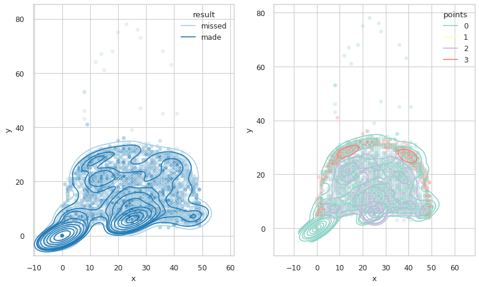

```python
#슛한 위치 확인
sns.set_style('whitegrid')
f, ax = plt.subplots(1, 2, figsize=(12, 7), dpi = 80)

#득점 성공/실패 분포
g1 = sns.scatterplot(data=lal2, x='x', y='y', hue='result', alpha = 0.3, palette='Paired', ax=ax[0])
g2 = sns.kdeplot(data=lal2, x='x', y='y', hue='result', palette='Paired', ax=ax[0])

#득점 점수 별 분포
g3 = sns.scatterplot(data=lal2, x='x', y='y', hue='points', alpha = 0.3, palette='Set3', ax=ax[1])
g4 = sns.kdeplot(data=lal2, x='x', y='y', hue='points', palette='Set3', ax=ax[1])

plt.show()
#(x, y) NaN -> 0
```

```python
#세부 행동 별 슛 위치
#Top 10
lal3 = lal2[lal2['type'].isin(lal2['type'].value_counts().head(10).index)]
lal3
```

|  | date | opponent | game_type | time | period | etype | team | player | result | points | type | x | y | datetime |
| --- | --- | --- | --- | --- | --- | --- | --- | --- | --- | --- | --- | --- | --- | --- |
| 1 | 2008-10-28 | POR | home | 11:39 | 1 | shot | LAL | Pau Gasol | missed | 0 | hook | 23.0 | 13.0 | 2008-10-28 11:39:00 |
| 2 | 2008-10-28 | POR | home | 11:37 | 1 | rebound | LAL | Vladimir Radmanovic | NaN | 0 | off | 0.0 | 0.0 | 2008-10-28 11:37:00 |
| 3 | 2008-10-28 | POR | home | 11:25 | 1 | shot | LAL | Derek Fisher | missed | 0 | layup | 25.0 | 6.0 | 2008-10-28 11:25:00 |
| 4 | 2008-10-28 | POR | home | 11:23 | 1 | rebound | LAL | Pau Gasol | NaN | 0 | off | 0.0 | 0.0 | 2008-10-28 11:23:00 |
| 5 | 2008-10-28 | POR | home | 11:22 | 1 | shot | LAL | Pau Gasol | made | 2 | hook | 25.0 | 10.0 | 2008-10-28 11:22:00 |
| ... | ... | ... | ... | ... | ... | ... | ... | ... | ... | ... | ... | ... | ... | ... |
| 34603 | 2009-04-14 | UTA | home | 2:12 | 4 | shot | LAL | Jordan Farmar | missed | 0 | jump | 40.0 | 7.0 | 2009-04-14 02:12:00 |
| 34605 | 2009-04-14 | UTA | home | 2:06 | 4 | foul | LAL | Jordan Farmar | NaN | 0 | shooting | 0.0 | 0.0 | 2009-04-14 02:06:00 |
| 34611 | 2009-04-14 | UTA | home | 1:27 | 4 | rebound | LAL | Josh Powell | NaN | 0 | def | 0.0 | 0.0 | 2009-04-14 01:27:00 |
| 34618 | 2009-04-14 | UTA | home | 0:42 | 4 | foul | LAL | Luke Walton | NaN | 0 | personal | 0.0 | 0.0 | 2009-04-14 00:42:00 |
| 34623 | 2009-04-14 | UTA | home | 0:20 | 4 | rebound | LAL | Luke Walton | NaN | 0 | def | 0.0 | 0.0 | 2009-04-14 00:20:00 |

10176 rows × 14 columns

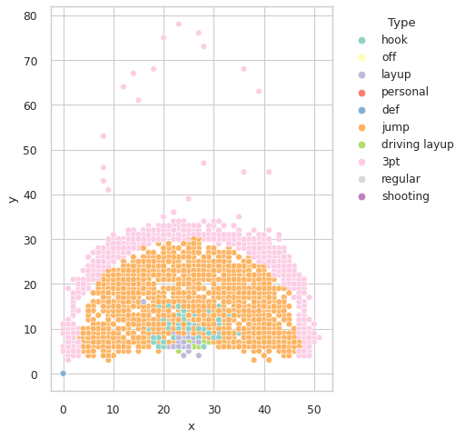

```python
#세부 행동 별 위치 확인
sns.set_style('whitegrid')
f, ax = plt.subplots(1, 1, figsize=(5, 7), dpi = 80)

sns.scatterplot(data=lal3, x='x', y='y', hue=lal3['type'], palette='Set3', ax=ax)

#Legend가 10개이기 때문에 그래프 안에 넣으면 혼란스럽다. 옆으로 빼 주자!
ax.legend(title='Type', bbox_to_anchor= (1.03, 1))

plt.show()
```